# Python group project Final_11thdec

## Project : AirbnbnBoros

### Team Members : Wei-Cheng, Dhruv Popat, Manasvi Prasad, Bhavin Kothari

## INTRODUCTION

[figure not shown]

#### We aim to analyze consumer behavior to conclude the factors that drive the popularity of listings. The factors we are most interested in are the keywords, types and amenities around the location of a listing. We hope to develop a robust analysis so that it can not only be used by Airbnb hosts and investors, but also by government to determine the best location and type of a new project.

#### An underlying assumption that we have made to analyze the data points here is that the number of reviews a listing has, directly correlates to the number of customer transactions and hence, the popularity of the listing. The reasoning behind this is that a listing can not have too many bad reviews, because a place gaining unpopularity would eventually not be receiving reservations and consequently not be reviewed.

#### At this point, we are primarily looking to analyze the impact the historic landmarks typically have on the listings, and what drives the popularity of the listings.

##### 1. What are the types of listings that people prefer in different areas?

##### 2. What kind of prices prevail in a certain location and what generates this price mechanism?

##### 3. What keyword in the listings attracts most customers?

##### 4. How the price, location, review per month affect the popularity for the listing(number of review)?

##### 5. How to predict price by using varibles?

##### 6. What area is preferred by hosts with maximum number of rooms?

[figure not shown]

### Importing packages, cause Python Programming!!

```python
%matplotlib inline
import pandas as pd
import matplotlib.pyplot as plt
import seaborn as sns
import numpy as np
from sklearn.preprocessing import PolynomialFeatures
import plotly.graph_objects as go
mapbox_access_token = 'pk.eyJ1IjoiZGhydXZwb3BhdCIsImEiOiJjazJwZXIzMzQwM2pqM2Ntb3ZlemF6ZWd0In0.an6SvHknkXmjTfPPTafbpw'
```

```python
#Scraping data from the Landmarks site for getting to know different landmarks in a Neighbourhood
National_parks_url = 'https://en.wikipedia.org/wiki/List_of_National_Historic_Landmarks_in_New_York_City'
National_parks = pd.read_html(National_parks_url, match = 'Landmark name')[0]
```

```python
#Extracting the 3 columns that we are interested in
National_parks_columns = National_parks[['Landmark name', 'County', 'Location']]
National_parks_columns.head()
```

|  | Landmark name | County | Location |
| --- | --- | --- | --- |
| 0 | 69th Regiment Armory | New York | Manhattan 40°44′30″N 73°59′01″W / 40.741648°... |
| 1 | Admiral David Glasgow Farragut Gravesite | Bronx | Bronx 40°53′32″N 73°51′57″W / 40.892165°N 73... |
| 2 | African Burial Ground | New York | Manhattan 40°42′52″N 74°00′16″W / 40.714558°... |
| 3 | Ambrose (lightship) | New York | Manhattan 40°42′17″N 74°00′09″W / 40.704844°... |
| 4 | American Stock Exchange Building | New York | Manhattan 40°42′32″N 74°00′45″W / 40.7090°N ... |

```python
#Check the data types for the columns
National_parks_columns.dtypes
```

```
Landmark name    object
County           object
Location         object
dtype: object
```

```python
#Clean the data in column 'Location' to get the value that we needed
National_parks_columns['Location'] = National_parks_columns['Location'].str.split(' ').str[0]
```

```python
#Renamning the colums of the website and get the number of landmarks in each neighbourhood_group
National_parks_columns_df = National_parks_columns.rename(columns={'County': 'neighbourhood_group'})
National_parks_columns_df = National_parks_columns_df.groupby('neighbourhood_group').count()['Location'].to_frame()
```

```python
National_parks_columns_df = National_parks_columns_df.reset_index()
```

```python
National_parks_columns_df['neighbourhood_group'].unique()
```

```
array(['Bronx', 'Kings', 'Kings and New York', 'New York', 'Queens',
       'Richmond (Staten Island)'], dtype=object)
```

```python
National_parks_columns_df['neighbourhood_group'] = ['Bronx', 'Brooklyn',
                                                 'Kings and New York', 'Manhattan', 'Queens',
                                                 'Staten Island']
```

```python
# The NYC airbnb data set
NYC_airbnb = pd.read_csv('python_airbnb.csv')
```

```python
NYC_airbnb['neighbourhood_group'].unique()
```

```
array(['Brooklyn', 'Manhattan', 'Queens', 'Staten Island', 'Bronx'],
      dtype=object)
```

### Merging the landmark data sets with NYC_airbnb

```python
Join_table = NYC_airbnb.merge(National_parks_columns_df,
                              left_on='neighbourhood_group', right_on='neighbourhood_group')
Join_table
```

[output not shown]

48895 rows × 17 columns

# Trying to find some correlation between price and number of reviews

```python
df1 = Join_table[Join_table['availability_365'] != 0]
df1[['number_of_reviews','price']].corr()
```

|  | number_of_reviews | price |
| --- | --- | --- |
| number_of_reviews | 1.000000 | -0.072919 |
| price | -0.072919 | 1.000000 |

#### We thought price would have a strong relation with number of reviews, but we find that there is no strict correlation between them.

# What type of listings cost the most and by how much do they differ?

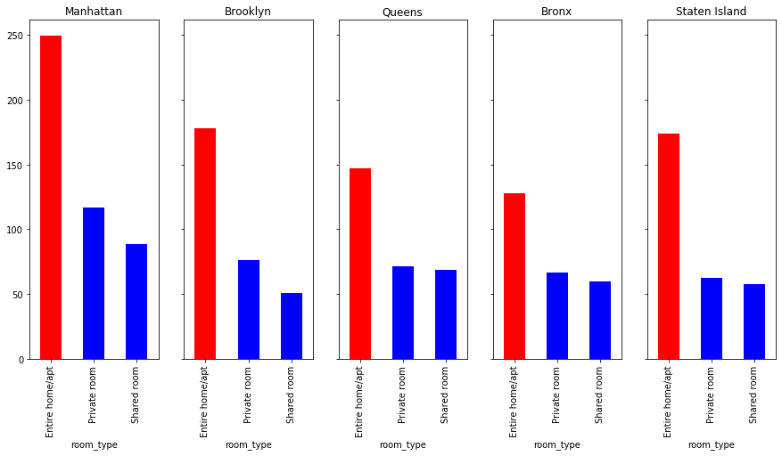

```python
fig, (ax, ax1, ax2, ax3, ax7) = plt.subplots(1, 5, sharey=True, figsize=(15,7))


df1 = Join_table[Join_table['neighbourhood_group'] == 'Manhattan'].reset_index()
df2 = Join_table[Join_table['neighbourhood_group'] == 'Brooklyn'].reset_index()
df3 = Join_table[Join_table['neighbourhood_group'] == 'Queens'].reset_index()
df4 = Join_table[Join_table['neighbourhood_group'] == 'Bronx'].reset_index()
df5 = Join_table[Join_table['neighbourhood_group'] == 'Staten Island'].reset_index()

group=df1.groupby('room_type')['price'].mean().plot.bar(ax=ax, color=['r','b','b'], title = 'Manhattan')
group2=df2.groupby('room_type')['price'].mean().plot.bar(ax=ax1, color=['r','b','b'], title='Brooklyn')
group3=df3.groupby('room_type')['price'].mean().plot.bar(ax=ax2, color=['r','b','b'], title='Queens')
group4=df4.groupby('room_type')['price'].mean().plot.bar(ax=ax3, color=['r','b','b'], title='Bronx')
group5=df5.groupby('room_type')['price'].mean().plot.bar(ax=ax7, color=['r','b','b'],title='Staten Island')
```

#### We note that private rooms in Manhattan cost almost as much as an entire appartment in Bronx. The contrast is not very stark between types of listings in Queens and Bronx

# Preferences of People in different boroughs

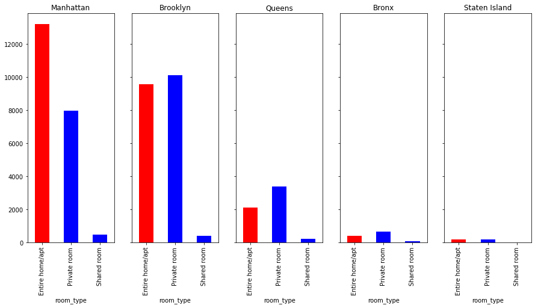

```python
fig, (ax, ax1, ax2, ax3, ax7) = plt.subplots(1, 5, sharey=True, figsize=(15,7))


df1 = Join_table[Join_table['neighbourhood_group'] == 'Manhattan'].reset_index()
df2 = Join_table[Join_table['neighbourhood_group'] == 'Brooklyn'].reset_index()
df3 = Join_table[Join_table['neighbourhood_group'] == 'Queens'].reset_index()
df4 = Join_table[Join_table['neighbourhood_group'] == 'Bronx'].reset_index()
df5 = Join_table[Join_table['neighbourhood_group'] == 'Staten Island'].reset_index()

group =df1.groupby('room_type')['price'].count().plot.bar(ax=ax, color=['r','b','b'], title = 'Manhattan')
group2=df2.groupby('room_type')['price'].count().plot.bar(ax=ax1, color=['r','b','b'], title='Brooklyn')
group3=df3.groupby('room_type')['price'].count().plot.bar(ax=ax2, color=['r','b','b'], title='Queens')
group4=df4.groupby('room_type')['price'].count().plot.bar(ax=ax3, color=['r','b','b'], title='Bronx')
group5=df5.groupby('room_type')['price'].count().plot.bar(ax=ax7, color=['r','b','b'],title='Staten Island')
```

#### We conclude that in Manhattan people prefer Entire Apartment and in Queens and Bronx private rooms are more prevalent. Can we conclude that people travelling to Manhattan often go with friends or in groups? What do you think causes this disparity?

# The trends of high end properties in NYC - A Visual Story

```python
L1 = []

for i in range(Join_table.shape[0]):
    if (Join_table['room_type'][i] == 'Private room' and Join_table['price'][i] > 250):
        L1.append(Join_table.iloc[i,:])

new_df = pd.DataFrame(L1)
new_df.head()
```

|  | id | name | host_id | host_name | neighbourhood_group | neighbourhood | latitude | longitude | room_type | price | minimum_nights | number_of_reviews | last_review | reviews_per_month | calculated_host_listings_count | availability_365 | Location |
| --- | --- | --- | --- | --- | --- | --- | --- | --- | --- | --- | --- | --- | --- | --- | --- | --- | --- |
| 148 | 80684 | Duplex w/ Terrace @ Box House Hotel | 417504 | The Box House Hotel | Brooklyn | Greenpoint | 40.73776 | -73.95327 | Private room | 349 | 3 | 8 | 3/27/2016 | 0.09 | 28 | 60 | 9 |
| 149 | 80700 | Loft w/ Terrace @ Box House Hotel | 417504 | The Box House Hotel | Brooklyn | Greenpoint | 40.73738 | -73.95482 | Private room | 349 | 3 | 7 | 5/24/2019 | 0.07 | 28 | 60 | 9 |
| 174 | 103311 | 2 BR w/ Terrace @ Box House Hotel | 417504 | The Box House Hotel | Brooklyn | Greenpoint | 40.73861 | -73.95485 | Private room | 599 | 3 | 9 | 5/19/2018 | 0.09 | 28 | 60 | 9 |
| 297 | 241140 | The Notorious B.N.B. { The Wallace } | 1177497 | Jessica | Brooklyn | Clinton Hill | 40.68975 | -73.96703 | Private room | 438 | 1 | 43 | 4/14/2019 | 0.46 | 11 | 363 | 9 |
| 299 | 242532 | The Notorious B.N.B. { The Swoon } | 1177497 | Jessica | Brooklyn | Clinton Hill | 40.68930 | -73.96602 | Private room | 279 | 1 | 120 | 6/19/2019 | 1.28 | 11 | 362 | 9 |

```python
class_map_data1 = go.Scattermapbox(


        lon = new_df[new_df['neighbourhood_group']=='Brooklyn' ]['longitude'] ,
        lat = new_df[new_df['neighbourhood_group']=='Brooklyn']['latitude'] ,
        text = new_df['name'],
        hoverinfo='text',
        mode = 'markers',
        marker = dict(
                    color = 'red',
                    symbol = 'circle',
                    opacity = .5
            ),
        name = "Brooklyn"
)

class_map_data2 = go.Scattermapbox(


        lon = new_df[new_df['neighbourhood_group']== 'Bronx'] ['longitude'],
        lat = new_df[new_df['neighbourhood_group']== 'Bronx'] ['latitude'],
        text = new_df['name'],
        hoverinfo='text',
        mode = 'markers',
        marker = dict(
                    color = 'blue',
                    symbol = 'circle',
                    opacity = .5
            ),
        name = "Bronx"
)


class_map_data3 = go.Scattermapbox(


        lon = new_df[new_df['neighbourhood_group']== 'Manhattan'] ['longitude'],
        lat = new_df[new_df['neighbourhood_group']== 'Manhattan'] ['latitude'],
        text = new_df['name'],
        hoverinfo='text',
        mode = 'markers',
        marker = dict(
                    color = 'yellow',
                    symbol = 'circle',
                    opacity = .5
            ),
        name = "Manhattan"
)


class_map_data4 = go.Scattermapbox(


        lon = new_df[new_df['neighbourhood_group']== 'Queens'] ['longitude'],
        lat = new_df[new_df['neighbourhood_group']== 'Queens'] ['latitude'],
        text = new_df['name'],
        hoverinfo='text',
        mode = 'markers',
        marker = dict(
                    color = 'purple',
                    symbol = 'circle',
                    opacity = .5
            ),
        name = "Queens"
)


class_map_data5 = go.Scattermapbox(


        lon = new_df[new_df['neighbourhood_group']== 'Staten Island'] ['longitude'],
        lat = new_df[new_df['neighbourhood_group']== 'Staten Island'] ['latitude'],
        text = new_df['name'],
        hoverinfo='text',
        mode = 'markers',
        marker = dict(
                    color = 'green',
                    symbol = 'circle',
                    opacity = .5
            ),
        name = "Staten Island"
)

class_map_layout = go.Layout(
        title = 'Distribution of Private Rooms whose price is above 250 Dollars in the 5 boroughs ',
        mapbox=go.layout.Mapbox(
            accesstoken=mapbox_access_token,
            zoom=1
        )
)

class_map2 = go.Figure(data=[class_map_data1, class_map_data2,class_map_data3,class_map_data4,class_map_data5], layout=class_map_layout)
class_map2.show()
```

[interactive chart not shown]

#### We can see that the most expensive houses are situated in Manhattan (Duh! Obviously)

# Do certain words in description have a better impact on the psyche of the tourist? Lets find out...

# Do certain words in description have a better impact on the psyche of the tourist? Lets find out...

```python
wordsSeries = Join_table['name'].str.split(' ')
wordsSeries
```

```
0              [Clean, &, quiet, apt, home, by, the, park]
1                    [Cozy, Entire, Floor, of, Brownstone]
2                                        [BlissArtsSpace!]
3        [Lovely, Room, 1,, Garden,, Best, Area,, Legal...
4                  [Only, 2, stops, to, Manhattan, studio]
5                 [Perfect, for, Your, Parents, +, Garden]
6        [Hip, Historic, Brownstone, Apartment, with, B...
7                   [Sweet, and, Spacious, Brooklyn, Loft]
8                      [CBG, CtyBGd, HelpsHaiti, rm#1:1-4]
9                            [CBG, Helps, Haiti, Room#2.5]
10                             [CBG, Helps, Haiti, Rm, #2]
11             [MAISON, DES, SIRENES1,bohemian, apartment]
12                [Sunny, Bedroom, Across, Prospect, Park]
13                [Loft, in, Williamsburg, Area, w/, Roof]
14                              [Large, B&B, Style, rooms]
```

[output cut: 47 more lines]

```python
wordsSeries = wordsSeries.dropna()
```

```python
dic = {}
for words in wordsSeries:
    for word in words:
        if word not in dic:
            dic[word] = 1
        else:
            dic[word] += 1
```

```python
import operator
sorted_dic = sorted(dic.items(), key=operator.itemgetter(1), reverse = True)
```

```python
from wordcloud import WordCloud, ImageColorGenerator
```

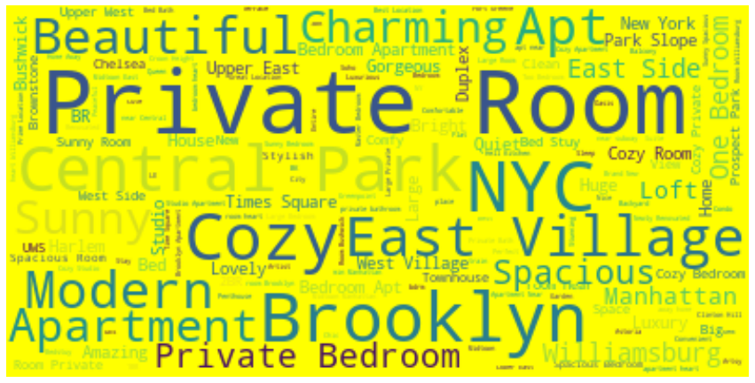

```python
#from wordcloud import WordCloud, ImageColorGenerator
text = " ".join(str(each) for each in Join_table.name)
# Create and generate a word cloud image:
wordcloud = WordCloud(max_words=200, background_color="yellow").generate(text)
plt.figure(figsize=(10,6))
plt.figure(figsize=(15,10))
# Display the generated image:
plt.imshow(wordcloud, interpolation='bilinear')
plt.axis("off")
plt.show()
```

```python
#printing some values of sorted_dic
sorted_dic[0:10]
```

```
[('in', 15796),
 ('Private', 4967),
 ('Room', 4803),
 ('room', 4165),
 ('Bedroom', 4124),
 ('Cozy', 3812),
 ('Apartment', 3633),
 ('to', 3560),
 ('Brooklyn', 3471),
 ('1', 3354)]
```

```python
MostFrequencyKeywords = ['Private','Brooklyn','Cozy','East','Studio','Spacious',
                         'Park','Williamsburg','Manhattan','Sunny','Village','Beautiful','Central',
                         'West','Large','Loft','Modern','Upper','Luxury','Side',
                         'Charming','heart','Bushwick','Bright']
# Etrack attractive description key words which appear more than 1000 times
```

```python
Join_table.head()
```

|  | id | name | host_id | host_name | neighbourhood_group | neighbourhood | latitude | longitude | room_type | price | minimum_nights | number_of_reviews | last_review | reviews_per_month | calculated_host_listings_count | availability_365 | Location |
| --- | --- | --- | --- | --- | --- | --- | --- | --- | --- | --- | --- | --- | --- | --- | --- | --- | --- |
| 0 | 2539 | Clean & quiet apt home by the park | 2787 | John | Brooklyn | Kensington | 40.64749 | -73.97237 | Private room | 149 | 1 | 9 | 10/19/2018 | 0.21 | 6 | 365 | 9 |
| 1 | 3831 | Cozy Entire Floor of Brownstone | 4869 | LisaRoxanne | Brooklyn | Clinton Hill | 40.68514 | -73.95976 | Entire home/apt | 89 | 1 | 270 | 7/5/2019 | 4.64 | 1 | 194 | 9 |
| 2 | 5121 | BlissArtsSpace! | 7356 | Garon | Brooklyn | Bedford-Stuyvesant | 40.68688 | -73.95596 | Private room | 60 | 45 | 49 | 10/5/2017 | 0.40 | 1 | 0 | 9 |
| 3 | 5803 | Lovely Room 1, Garden, Best Area, Legal rental | 9744 | Laurie | Brooklyn | South Slope | 40.66829 | -73.98779 | Private room | 89 | 4 | 167 | 6/24/2019 | 1.34 | 3 | 314 | 9 |
| 4 | 6848 | Only 2 stops to Manhattan studio | 15991 | Allen & Irina | Brooklyn | Williamsburg | 40.70837 | -73.95352 | Entire home/apt | 140 | 2 | 148 | 6/29/2019 | 1.20 | 1 | 46 | 9 |

```python
nameReivew = Join_table[['id', 'name', 'reviews_per_month']]
```

```python
nameReivew.head()
```

|  | id | name | reviews_per_month |
| --- | --- | --- | --- |
| 0 | 2539 | Clean & quiet apt home by the park | 0.21 |
| 1 | 3831 | Cozy Entire Floor of Brownstone | 4.64 |
| 2 | 5121 | BlissArtsSpace! | 0.40 |
| 3 | 5803 | Lovely Room 1, Garden, Best Area, Legal rental | 1.34 |
| 4 | 6848 | Only 2 stops to Manhattan studio | 1.20 |

```python
nameReivew = nameReivew.dropna()
```

```python
nameReivew = nameReivew.reset_index(drop = True)
```

```python
len(MostFrequencyKeywords)
```

```
24
```

```python
dictOfWords = { i : [] for i in MostFrequencyKeywords }
```

```python
nameReivew['name'] = nameReivew['name'].str.split(' ')
```

```python
for i in range(len(nameReivew['name'])):
        for keyword in MostFrequencyKeywords:
            if keyword in nameReivew['name'][i]:
                dictOfWords[keyword].append(nameReivew['reviews_per_month'][i])
```

```python
for keyword in dictOfWords:
    dictOfWords[keyword] = sum(dictOfWords[keyword])/len(dictOfWords[keyword])
```

```python
dictOfWords
```

```
{'Private': 1.6672492552135085,
 'Brooklyn': 1.2967902946273835,
 'Cozy': 1.4868643533123058,
 'East': 1.1243124999999985,
 'Studio': 1.225477528089885,
 'Spacious': 1.093484646194924,
 'Park': 1.3390996784565898,
 'Williamsburg': 1.029652025099829,
 'Manhattan': 1.6153231939163528,
 'Sunny': 1.0504221165279417,
 'Village': 1.00542800265428,
 'Beautiful': 1.2678580645161273,
 'Central': 1.6136567164179088,
 'West': 0.953128103277061,
 'Large': 1.051615320566193,
 'Loft': 1.0424311490978153,
 'Modern': 1.4621062271062277,
 'Upper': 1.0367185761957733,
 'Luxury': 1.2473290598290592,
 'Side': 1.0943550295857989,
 'Charming': 1.2054754098360634,
 'heart': 1.285463800904976,
 'Bushwick': 1.2145668316831688,
 'Bright': 1.196271739130435}
```

```python
key = list(dictOfWords.keys())
```

```python
value = list(dictOfWords.values())
```

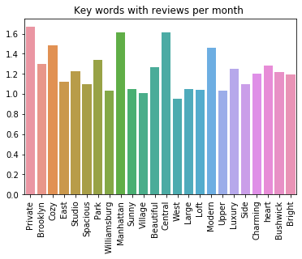

```python
sns.barplot(x=key, y= value)
plt.xticks(rotation=90)
plt.title("Key words with reviews per month ")
```

```python
avg = sum(nameReivew['reviews_per_month'])/len(nameReivew['reviews_per_month'])
```

```python
avg
```

```
1.3734098926281644
```

```python
for i in dictOfWords:
    if dictOfWords[i] > avg:
        print('When {} is in the description, average reviews per month go to {}'.format(i, dictOfWords[i]))
```

```
When Private is in the description, average reviews per month go to 1.6672492552135085
When Cozy is in the description, average reviews per month go to 1.4868643533123058
When Manhattan is in the description, average reviews per month go to 1.6153231939163528
When Central is in the description, average reviews per month go to 1.6136567164179088
When Modern is in the description, average reviews per month go to 1.4621062271062277
```

### As observed, Private, Cozy, Manhattan, Central and Modern are 5 words that have outstanding rate of reviews per month and these are the few of several popular words that both hosts and guests could look for.

# How the price affect the popularity for the listing(number of review)?

```python
Join_table.head()
```

|  | id | name | host_id | host_name | neighbourhood_group | neighbourhood | latitude | longitude | room_type | price | minimum_nights | number_of_reviews | last_review | reviews_per_month | calculated_host_listings_count | availability_365 | Location |
| --- | --- | --- | --- | --- | --- | --- | --- | --- | --- | --- | --- | --- | --- | --- | --- | --- | --- |
| 0 | 2539 | Clean & quiet apt home by the park | 2787 | John | Brooklyn | Kensington | 40.64749 | -73.97237 | Private room | 149 | 1 | 9 | 10/19/2018 | 0.21 | 6 | 365 | 9 |
| 1 | 3831 | Cozy Entire Floor of Brownstone | 4869 | LisaRoxanne | Brooklyn | Clinton Hill | 40.68514 | -73.95976 | Entire home/apt | 89 | 1 | 270 | 7/5/2019 | 4.64 | 1 | 194 | 9 |
| 2 | 5121 | BlissArtsSpace! | 7356 | Garon | Brooklyn | Bedford-Stuyvesant | 40.68688 | -73.95596 | Private room | 60 | 45 | 49 | 10/5/2017 | 0.40 | 1 | 0 | 9 |
| 3 | 5803 | Lovely Room 1, Garden, Best Area, Legal rental | 9744 | Laurie | Brooklyn | South Slope | 40.66829 | -73.98779 | Private room | 89 | 4 | 167 | 6/24/2019 | 1.34 | 3 | 314 | 9 |
| 4 | 6848 | Only 2 stops to Manhattan studio | 15991 | Allen & Irina | Brooklyn | Williamsburg | 40.70837 | -73.95352 | Entire home/apt | 140 | 2 | 148 | 6/29/2019 | 1.20 | 1 | 46 | 9 |

```python
%pylab inline
import datetime as dt
import pandas as pd
import seaborn as sns
import statsmodels.api as sm
```

```python
Join_table['price'].describe()
```

```
count    48895.000000
mean       152.720687
std        240.154170
min          0.000000
25%         69.000000
50%        106.000000
75%        175.000000
max      10000.000000
Name: price, dtype: float64
```

```python
Join_table = Join_table.dropna()
```

```python
Join_table['price_bin'] = pd.cut(x=Join_table['price'], bins=[0,69,106,175,10000])
```

```python
Join_table.head()
```

|  | id | name | host_id | host_name | neighbourhood_group | neighbourhood | latitude | longitude | room_type | price | minimum_nights | number_of_reviews | last_review | reviews_per_month | calculated_host_listings_count | availability_365 | Location | price_bin |
| --- | --- | --- | --- | --- | --- | --- | --- | --- | --- | --- | --- | --- | --- | --- | --- | --- | --- | --- |
| 0 | 2539 | Clean & quiet apt home by the park | 2787 | John | Brooklyn | Kensington | 40.64749 | -73.97237 | Private room | 149 | 1 | 9 | 10/19/2018 | 0.21 | 6 | 365 | 9 | (106, 175] |
| 1 | 3831 | Cozy Entire Floor of Brownstone | 4869 | LisaRoxanne | Brooklyn | Clinton Hill | 40.68514 | -73.95976 | Entire home/apt | 89 | 1 | 270 | 7/5/2019 | 4.64 | 1 | 194 | 9 | (69, 106] |
| 2 | 5121 | BlissArtsSpace! | 7356 | Garon | Brooklyn | Bedford-Stuyvesant | 40.68688 | -73.95596 | Private room | 60 | 45 | 49 | 10/5/2017 | 0.40 | 1 | 0 | 9 | (0, 69] |
| 3 | 5803 | Lovely Room 1, Garden, Best Area, Legal rental | 9744 | Laurie | Brooklyn | South Slope | 40.66829 | -73.98779 | Private room | 89 | 4 | 167 | 6/24/2019 | 1.34 | 3 | 314 | 9 | (69, 106] |
| 4 | 6848 | Only 2 stops to Manhattan studio | 15991 | Allen & Irina | Brooklyn | Williamsburg | 40.70837 | -73.95352 | Entire home/apt | 140 | 2 | 148 | 6/29/2019 | 1.20 | 1 | 46 | 9 | (106, 175] |

# Graph of number of reviews by Price range in different neighbourhood groups

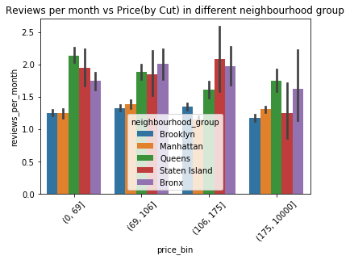

```python
sns.barplot(x=Join_table['price_bin'], y=Join_table['reviews_per_month'], hue=Join_table['neighbourhood_group']);
plt.xticks(rotation=45);
plt.title("Reviews per month vs Price(by Cut) in different neighbourhood group")
```

# Predict price by using Linear Regression

### Having converted the room types and neighbourhood groups to numerical categorical data and having removed the data of availability_365 = 0 from our considerations as it's unlikely that owners don't bother to rent out their homes even once a year have updated prices, we hope to attain a better model. We have used Heatmap to check the disturbing factor of intermediate variables and select the variable to our regression model. We have also removed outliers by observing the graph plotted by error_frame and have fit the model again. As expected, this model is much better than before as R2 value is higher and Actual and Predicted model have much better fitting.

```python
%matplotlib inline
import numpy as np
import pandas as pd
import matplotlib.pyplot as plt
```

```python
Join_table = Join_table.rename(columns={'name': 'Description', 'id':'RoomId','Location':'Numbers of Landmark in neighbourhood_group' })
```

```python
df = Join_table.copy()
df.head()
```

|  | RoomId | Description | host_id | host_name | neighbourhood_group | neighbourhood | latitude | longitude | room_type | price | minimum_nights | number_of_reviews | last_review | reviews_per_month | calculated_host_listings_count | availability_365 | Numbers of Landmark in neighbourhood_group | price_bin |
| --- | --- | --- | --- | --- | --- | --- | --- | --- | --- | --- | --- | --- | --- | --- | --- | --- | --- | --- |
| 0 | 2539 | Clean & quiet apt home by the park | 2787 | John | Brooklyn | Kensington | 40.64749 | -73.97237 | Private room | 149 | 1 | 9 | 10/19/2018 | 0.21 | 6 | 365 | 9 | (106, 175] |
| 1 | 3831 | Cozy Entire Floor of Brownstone | 4869 | LisaRoxanne | Brooklyn | Clinton Hill | 40.68514 | -73.95976 | Entire home/apt | 89 | 1 | 270 | 7/5/2019 | 4.64 | 1 | 194 | 9 | (69, 106] |
| 2 | 5121 | BlissArtsSpace! | 7356 | Garon | Brooklyn | Bedford-Stuyvesant | 40.68688 | -73.95596 | Private room | 60 | 45 | 49 | 10/5/2017 | 0.40 | 1 | 0 | 9 | (0, 69] |
| 3 | 5803 | Lovely Room 1, Garden, Best Area, Legal rental | 9744 | Laurie | Brooklyn | South Slope | 40.66829 | -73.98779 | Private room | 89 | 4 | 167 | 6/24/2019 | 1.34 | 3 | 314 | 9 | (69, 106] |
| 4 | 6848 | Only 2 stops to Manhattan studio | 15991 | Allen & Irina | Brooklyn | Williamsburg | 40.70837 | -73.95352 | Entire home/apt | 140 | 2 | 148 | 6/29/2019 | 1.20 | 1 | 46 | 9 | (106, 175] |

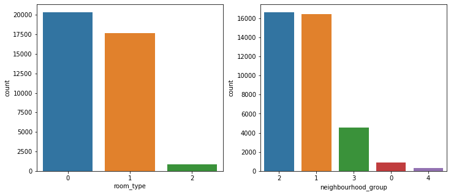

```python
#Convert the room types and neighbourhood groups to numerical categorical data.
df['room_type'] = df['room_type'].astype('category').cat.codes
df['neighbourhood_group'] = df['neighbourhood_group'].astype('category').cat.codes
f, axs = plt.subplots(1,2, figsize=(12,5))
sns.countplot(df['room_type'], ax=axs[0], order=df['room_type'].value_counts().index)
sns.countplot(df['neighbourhood_group'],order=df['neighbourhood_group'].value_counts().index, ax=axs[1])
```

### Many owners don't rent out their properties for even a single day in an year.

### It's unlikely that owners that don't bother to rent out their homes even once a year are updated with the prices, so we will remove them from our considerations.

```python
print(df.shape)
df = df[df['availability_365']!=0]
print(df.shape) #New DF shape
```

```
(38821, 18)
(26146, 18)
```

```python
df.head()
```

|  | RoomId | Description | host_id | host_name | neighbourhood_group | neighbourhood | latitude | longitude | room_type | price | minimum_nights | number_of_reviews | last_review | reviews_per_month | calculated_host_listings_count | availability_365 | Numbers of Landmark in neighbourhood_group | price_bin |
| --- | --- | --- | --- | --- | --- | --- | --- | --- | --- | --- | --- | --- | --- | --- | --- | --- | --- | --- |
| 0 | 2539 | Clean & quiet apt home by the park | 2787 | John | 1 | Kensington | 40.64749 | -73.97237 | 1 | 149 | 1 | 9 | 10/19/2018 | 0.21 | 6 | 365 | 9 | (106, 175] |
| 1 | 3831 | Cozy Entire Floor of Brownstone | 4869 | LisaRoxanne | 1 | Clinton Hill | 40.68514 | -73.95976 | 0 | 89 | 1 | 270 | 7/5/2019 | 4.64 | 1 | 194 | 9 | (69, 106] |
| 3 | 5803 | Lovely Room 1, Garden, Best Area, Legal rental | 9744 | Laurie | 1 | South Slope | 40.66829 | -73.98779 | 1 | 89 | 4 | 167 | 6/24/2019 | 1.34 | 3 | 314 | 9 | (69, 106] |
| 4 | 6848 | Only 2 stops to Manhattan studio | 15991 | Allen & Irina | 1 | Williamsburg | 40.70837 | -73.95352 | 0 | 140 | 2 | 148 | 6/29/2019 | 1.20 | 1 | 46 | 9 | (106, 175] |
| 5 | 7097 | Perfect for Your Parents + Garden | 17571 | Jane | 1 | Fort Greene | 40.69169 | -73.97185 | 0 | 215 | 2 | 198 | 6/28/2019 | 1.72 | 1 | 321 | 9 | (175, 10000] |

```python
df.drop(['RoomId', 'Description', 'host_id', 'host_name', 'neighbourhood', 'last_review'], axis=1, inplace=True)
```

```python
df.drop(['price_bin'], axis=1, inplace=True)
```

```python
df.head()
```

|  | neighbourhood_group | latitude | longitude | room_type | price | minimum_nights | number_of_reviews | reviews_per_month | calculated_host_listings_count | availability_365 | Numbers of Landmark in neighbourhood_group |
| --- | --- | --- | --- | --- | --- | --- | --- | --- | --- | --- | --- |
| 0 | 1 | 40.64749 | -73.97237 | 1 | 149 | 1 | 9 | 0.21 | 6 | 365 | 9 |
| 1 | 1 | 40.68514 | -73.95976 | 0 | 89 | 1 | 270 | 4.64 | 1 | 194 | 9 |
| 3 | 1 | 40.66829 | -73.98779 | 1 | 89 | 4 | 167 | 1.34 | 3 | 314 | 9 |
| 4 | 1 | 40.70837 | -73.95352 | 0 | 140 | 2 | 148 | 1.20 | 1 | 46 | 9 |
| 5 | 1 | 40.69169 | -73.97185 | 0 | 215 | 2 | 198 | 1.72 | 1 | 321 | 9 |

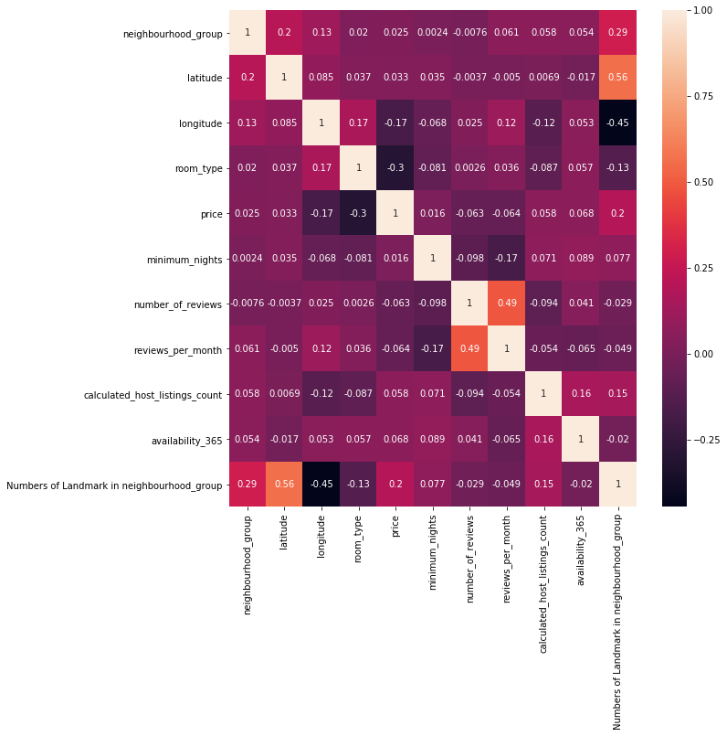

```python
plt.figure(figsize=(10,10))
sns.heatmap(df.corr().round(4), annot=True)
```

### Heatmap to check the disturbing factor of intermediate variables

```python
from sklearn import preprocessing
from sklearn.model_selection import train_test_split
Y = df['price']
X = df[['neighbourhood_group', 'longitude', 'room_type', 'availability_365', 'calculated_host_listings_count',
        'Numbers of Landmark in neighbourhood_group', 'reviews_per_month','latitude','number_of_reviews']]
X = preprocessing.normalize(X)
X = np.hstack((np.ones( (len(df['price']) ,1)), X))

X_train, X_test, Y_train, Y_test = train_test_split(X, Y, test_size = 0.2)
print(X_train.shape)
print(X_test.shape)
print(Y_train.shape)
print(Y_test.shape)
```

```
(20916, 10)
(5230, 10)
(20916,)
(5230,)
```

```python
from sklearn.linear_model import LinearRegression
from sklearn.metrics import mean_squared_error,r2_score

lin_model = LinearRegression().fit(X_train, Y_train)
```

```python
y_train_predict = lin_model.predict(X_train)
rmse = (np.sqrt(mean_squared_error(Y_train, y_train_predict)))
r2 = r2_score(Y_train, y_train_predict)

print("The model performance for training set")
print("--------------------------------------")
print('RMSE is {}'.format(rmse))
print('R2 score is {}'.format(r2))
print("\n")

# model evaluation for testing set
y_test_predict = lin_model.predict(X_test)
rmse = (np.sqrt(mean_squared_error(Y_test, y_test_predict)))
r2 = r2_score(Y_test, y_test_predict)

print("The model performance for testing set")
print("--------------------------------------")
print('RMSE is {}'.format(rmse))
print('R2 score is {}'.format(r2))
```

```
The model performance for training set
--------------------------------------
RMSE is 187.72392443782243
R2 score is 0.0971370164195614


The model performance for testing set
--------------------------------------
RMSE is 194.6402628160994
R2 score is 0.08853676083786555
```

### Lower values of RMSE indicate better fit. RMSE is a good measure of how accurately the model predicts the response, and it is the most important criterion for fit if the main purpose of the model is prediction

```python
error_frame = pd.DataFrame({'Actual': np.array(Y_test).flatten(), 'Predicted': y_test_predict.flatten()})
error_frame.head(10)
```

|  | Actual | Predicted |
| --- | --- | --- |
| 0 | 140 | 148.775851 |
| 1 | 125 | 116.472905 |
| 2 | 130 | 229.837177 |
| 3 | 90 | 222.731884 |
| 4 | 33 | 120.560247 |
| 5 | 95 | 7.360453 |
| 6 | 70 | 54.432198 |
| 7 | 125 | 147.718261 |
| 8 | 256 | 239.106587 |
| 9 | 80 | 123.268393 |

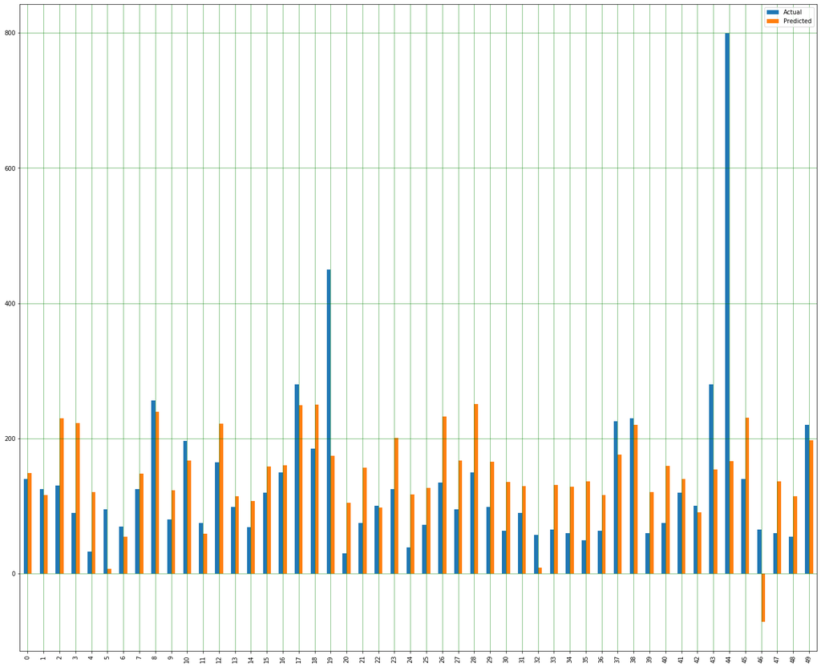

```python
df1 = error_frame[:50]
df1.plot(kind='bar',figsize=(24,20))
plt.grid(which='major', linestyle='-', linewidth='0.5', color='green')
plt.grid(which='minor', linestyle=':', linewidth='0.5', color='black')
plt.show()
```

# Since Our R2 score is very bad, our model is not perfect. So we remove outliers and try to fit it again.

```python
#We will use the IQR metric to remove outliers, then fit again.
Q1 = df.quantile(0.25)
Q3 = df.quantile(0.75)
IQR = Q3 - Q1
```

```python
IQR_df = df[~((df < (Q1 - 1.5 * IQR)) |(df > (Q3 + 1.5 * IQR))).any(axis=1)]
IQR_df.shape
```

```
(15945, 11)
```

```python
df.head()
```

|  | neighbourhood_group | latitude | longitude | room_type | price | minimum_nights | number_of_reviews | reviews_per_month | calculated_host_listings_count | availability_365 | Numbers of Landmark in neighbourhood_group |
| --- | --- | --- | --- | --- | --- | --- | --- | --- | --- | --- | --- |
| 0 | 1 | 40.64749 | -73.97237 | 1 | 149 | 1 | 9 | 0.21 | 6 | 365 | 9 |
| 1 | 1 | 40.68514 | -73.95976 | 0 | 89 | 1 | 270 | 4.64 | 1 | 194 | 9 |
| 3 | 1 | 40.66829 | -73.98779 | 1 | 89 | 4 | 167 | 1.34 | 3 | 314 | 9 |
| 4 | 1 | 40.70837 | -73.95352 | 0 | 140 | 2 | 148 | 1.20 | 1 | 46 | 9 |
| 5 | 1 | 40.69169 | -73.97185 | 0 | 215 | 2 | 198 | 1.72 | 1 | 321 | 9 |

```python
Y = IQR_df['price']
X = IQR_df[['neighbourhood_group', 'longitude', 'room_type', 'availability_365', 'calculated_host_listings_count',
        'Numbers of Landmark in neighbourhood_group', 'reviews_per_month','latitude','number_of_reviews']]
X = preprocessing.normalize(X)
X = np.hstack((np.ones( (len(IQR_df['price']) ,1)), X))


X_train, X_test, Y_train, Y_test = train_test_split(X, Y, test_size = 0.2)
print(X_train.shape)
print(X_test.shape)
print(Y_train.shape)
print(Y_test.shape)
```

```
(12756, 10)
(3189, 10)
(12756,)
(3189,)
```

```python
lin_model = LinearRegression().fit(X_train, Y_train)
y_train_predict = lin_model.predict(X_train)
rmse = (np.sqrt(mean_squared_error(Y_train, y_train_predict)))
r2 = r2_score(Y_train, y_train_predict)

print("The model performance for training set")
print("--------------------------------------")
print('RMSE is {}'.format(rmse))
print('R2 score is {}'.format(r2))
print("\n")

# model evaluation for testing set
y_test_predict = lin_model.predict(X_test)
rmse = (np.sqrt(mean_squared_error(Y_test, y_test_predict)))
r2 = r2_score(Y_test, y_test_predict)

print("The model performance for testing set")
print("--------------------------------------")
print('RMSE is {}'.format(rmse))
print('R2 score is {}'.format(r2))
```

```
The model performance for training set
--------------------------------------
RMSE is 53.84646399226288
R2 score is 0.38410662408608454


The model performance for testing set
--------------------------------------
RMSE is 53.98040774965494
R2 score is 0.3909952765044771
```

```python
error_frame = pd.DataFrame({'Actual': np.array(Y_test).flatten(), 'Predicted': y_test_predict.flatten()})
error_frame.head(10)
```

|  | Actual | Predicted |
| --- | --- | --- |
| 0 | 76 | 125.866390 |
| 1 | 201 | 146.282402 |
| 2 | 68 | 85.611016 |
| 3 | 135 | 145.239810 |
| 4 | 59 | 105.842217 |
| 5 | 125 | 190.073092 |
| 6 | 209 | 151.105008 |
| 7 | 240 | 103.532930 |
| 8 | 160 | 185.934384 |
| 9 | 183 | 184.555371 |

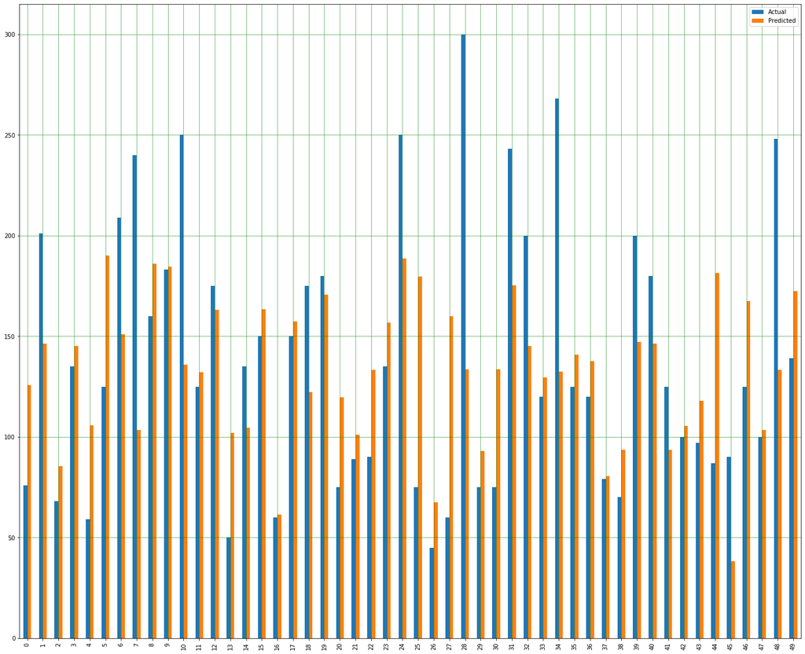

```python
df1 = error_frame[:50]
df1.plot(kind='bar',figsize=(24,20))
plt.grid(which='major', linestyle='-', linewidth='0.5', color='green')
plt.grid(which='minor', linestyle=':', linewidth='0.5', color='black')
plt.show()
```

# This model is much better than before as R2 value is higher and Actual and Predicted model have much better fitting

## Finding top hosts and which borough they prefer

```python
import plotly.graph_objects as go

temp = Join_table.host_id.value_counts().reset_index().head(20)
temp.columns = ['host_id', 'count']
temp = temp.merge(Join_table[['host_id','host_name']], left_on = 'host_id',right_on = 'host_id', how = 'left', copy = False)
temp.drop_duplicates(inplace = True)

x = temp['host_name']
y = temp['count']

# Use the hovertext kw argument for hover text
fig = go.Figure(data=[go.Bar(x=x,y=y)])
# Customize aspect
fig.update_traces(marker_color='rgb(158,202,225)', marker_line_color='rgb(8,48,107)',
                  marker_line_width=1.5, opacity=0.6)
fig.update_layout(title_text='Top Airbnb hosts in NYC')
fig.layout.xaxis.title = 'Hosts'
fig.layout.yaxis.title = 'Host listings'
fig.show()
```

[interactive chart not shown]

```python
import plotly.express as px
## Setting the DataFrame
temp = Join_table.host_id.value_counts().reset_index().head(5)
temp.columns = ['host_id', 'count']
temp = temp.merge(Join_table[['host_id','host_name','price', 'latitude','longitude']], left_on = 'host_id',right_on = 'host_id', how = 'left', copy = False)

## Setting up the Visualization..
fig = px.scatter_mapbox(temp,
                        lat="latitude",
                        lon="longitude",
                        color="host_name",
                        size="price",
                        size_max=30,
                        opacity = .70,
                        zoom=11,
                       )

fig.layout.mapbox.style = 'carto-positron'
fig.update_layout(title_text = 'Top 5 hosts and their hosted Locations<br>(Click legend to toggle hosts)', height = 800)

fig.show()
```

[interactive chart not shown]

# Upon analysing the map, we come to the conclusion that people prefer to rent out their home more in Manhattan and the bubble size indicates that most of the money earned by the top host-Sonder is by renting houses in Downtown Manhattan.